# ch10_sum

##### **Root Morphology**

- **Length:** Optimal removal when 1/3 to 2/3 formed (blunt ends). Fully formed roots increase fracture risk. Less than 1/3 formed roots can “roll” in the socket, making removal difficult.
- **Fusion:** Fused, conical roots are less difficult than separate, distinct roots.
- **Curvature:** Severely curved or dilacerated roots are more difficult; sharply hooked roots are challenging. Direction of curvature (e.g., distal curve for mesioangular impaction) affects difficulty.
- **Width:** If root width is greater than cervical line width, more bone removal or sectioning is needed.
- **Periodontal Ligament (PDL) Space:** Wider PDL space (common in younger patients) simplifies removal. Narrower PDL space (common in older patients >40) increases difficulty.

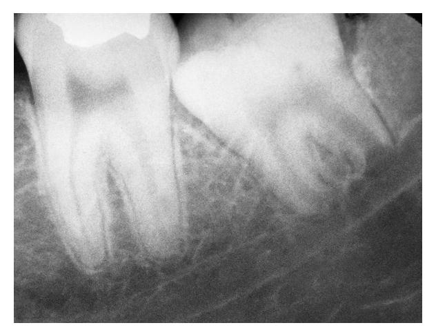

$\bullet$ Fig. 10.29 Roots that are two-thirds formed, which are less difficult to remove than if fully formed.

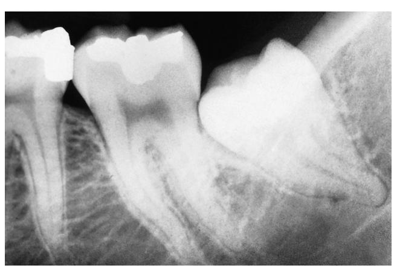

• Fig. 10.31 Fused roots with a conical shape.

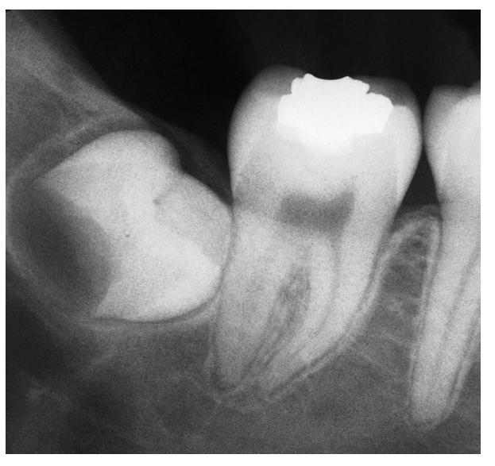

• Fig. 10.30 Lack of root development. If extraction is attempted, the crown will often roll around in the socket, making it difficult to remove.

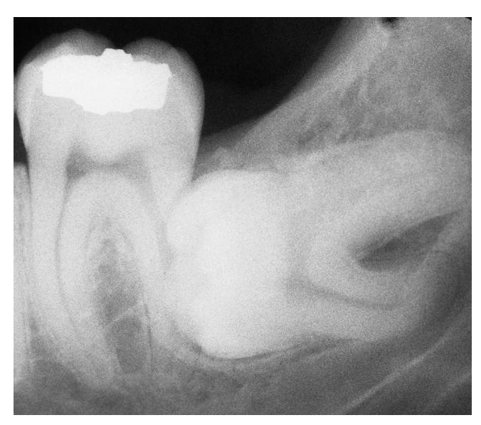

Fig. 10.32 Divergent roots with severe curvature. Such roots are more difficult to remove.

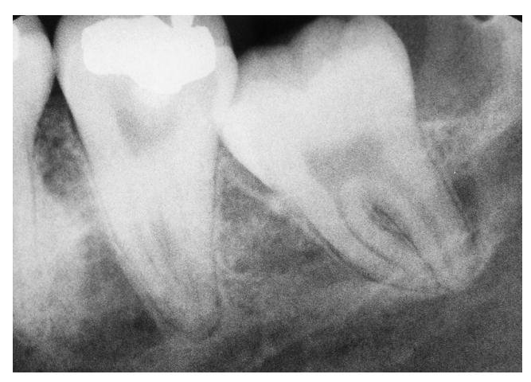

• Fig. 10.33 Wide periodontal ligament space. The widened space makes the extraction process less difficult.

##### **Size of the Follicular Sac**

- **Wide follicular sac (almost cystic):** Requires less bone removal, simplifying extraction (more common in young patients).
- **Narrow/nonexistent follicular space:** Requires the surgeon to create space, increasing difficulty and time.

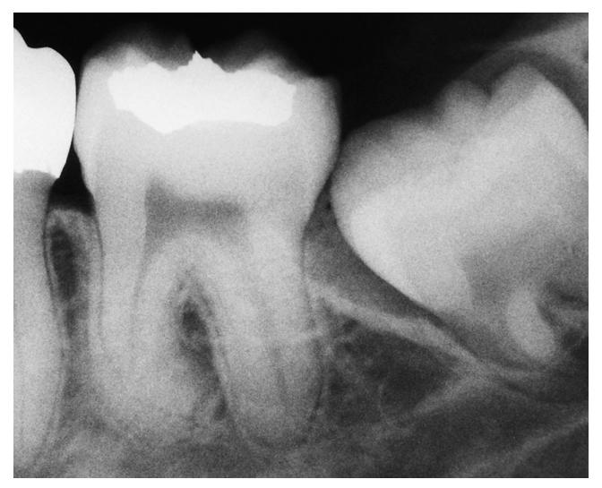

• Fig. 10.34 Large follicular sac. When the space of the sac is large, the amount of bone removal required is decreased.

##### **Density of Surrounding Bone**

- **Determination:** Best assessed by patient’s age (radiographic interpretation is unreliable). Gender also influences bone density (males generally have greater density).
- **Younger patients (≤25 years):** Less dense, pliable, expandable bone; easier to cut with a burr.
- **Older patients (>25 years):** Denser, less flexible bone; requires removal of all interfering bone, takes longer with a burr, higher risk of fracture.

##### **Contact With Mandibular Second Molar**

- **Space Present:** Extraction is more straightforward, with less risk to the second molar.
- **Direct Contact (distoangular or horizontal impaction):** Requires caution with elevators and burr to avoid injuring the second molar (especially if carious, heavily restored, or endodontically treated). Patient must be forewarned.

##### **Relationship to Inferior Alveolar Nerve**

- Mandibular third molar roots often superimpose on the inferior alveolar canal radiographically.
- **Risk:** Damage to the inferior alveolar nerve can cause altered sensation (paresthesia or anesthesia) of the lower lip and chin, usually transient but rarely permanent.
- **Precaution:** Special care is needed if roots are close to the canal, greatly increasing procedural difficulty.
- **CBCT:** Aids in accurate preoperative assessment of the root-canal relationship.

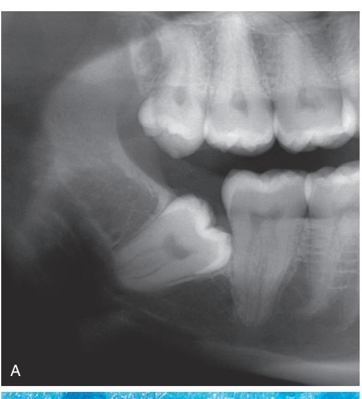

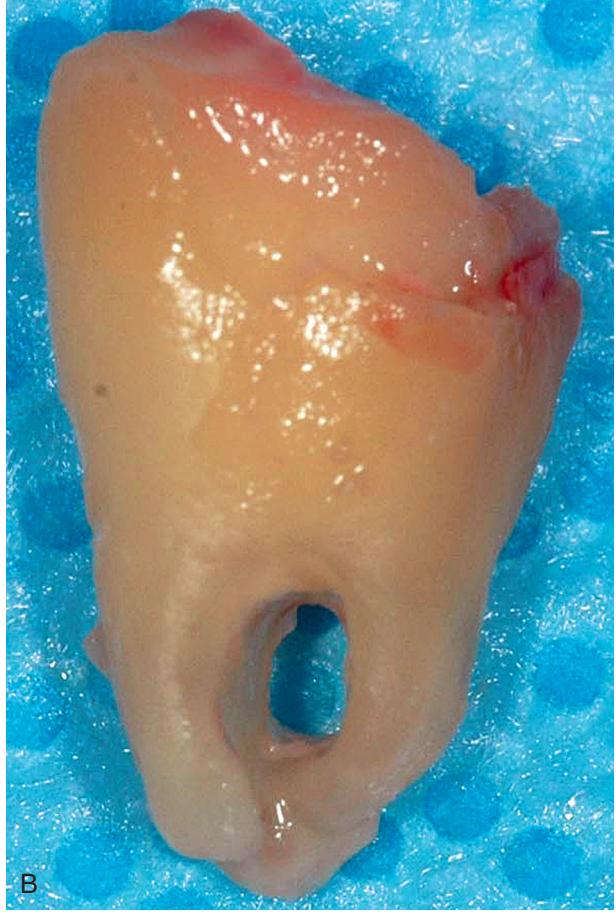

• Fig. 10.35 (A) Radiographic view of the mandibular third molar that suggests proximity to the inferior alveolar nerve. (B) Hole through the root of the third molar seen in the radiograph after removal. During removal, the inferior alveolar neurovascular bundle was severed. (Courtesy Dr. Edward Ellis III.)

##### **Nature of Overlying Tissue**

This insurance-based classification system often does not correlate with actual surgical difficulty but is used for billing.

- **Soft Tissue Impaction:** Crown is covered only by soft tissue (height of contour above alveolar bone). Requires soft tissue incision and flap reflection.
- **Partial Bony Impaction:** Superficial portion is covered by soft tissue, but at least part of the height of contour is below alveolar bone. Requires flap reflection and bone removal; may also need tooth division.
- **Complete Bony Impaction:** Tooth is completely encased in bone and not visible after flap reflection. Requires extensive bone removal and almost always tooth sectioning.

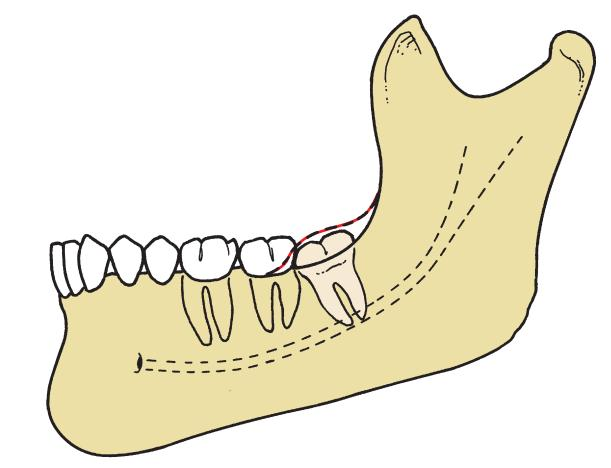

• Fig. 10.36 Soft tissue impaction in which the crown of the tooth is covered by soft tissue only and can be removed without bone removal.

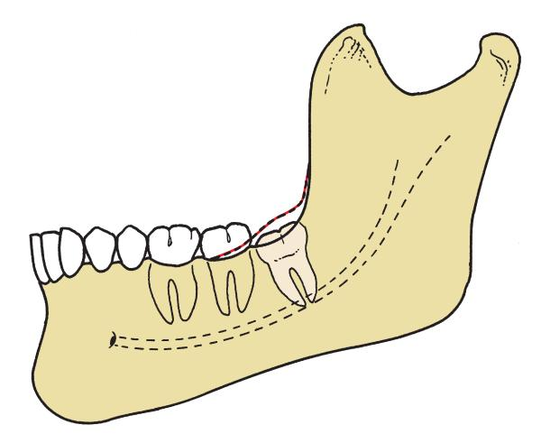

• Fig. 10.37 Partial bony impaction in which part of the tooth—usually a posterior aspect—is covered with bone and requires bone removal or tooth sectioning for extraction.

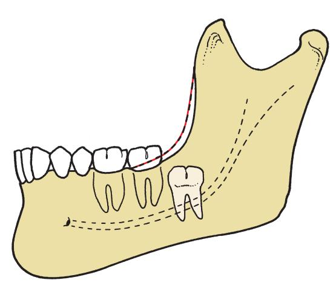

• Fig. 10.38 Complete bony impaction in which the tooth is completely covered with bone and requires extensive removal of bone for extraction.

#### **Summary of Difficulty Factors**

##### **BOX 10.1 Factors That Make Impaction Surgery Less Difficult**

1. Mesioangular position
2. Pell and Gregory class 1 ramus
3. Pell and Gregory class A depth
4. Roots one-third to two-thirds formed<sup>a</sup>
5. Fused conical roots
6. Wide periodontal ligament<sup>a</sup>
7. Large follicle<sup>a</sup>
8. Elastic bone<sup>a</sup>
9. Separated from second molar
10. Separated from inferior alveolar nerve<sup>a</sup>
11. Soft tissue impaction

<sup>a</sup>Present in the young patient.

##### **BOX 10.2 Factors That Make Impaction Surgery More Difficult**

1. Distoangular position
2. Pell and Gregory class 2 or 3 ramus
3. Pell and Gregory class B or C depth
4. Long, thin roots<sup>a</sup>
5. Divergent, curved roots
6. Narrow periodontal ligament
7. Thin follicle<sup>a</sup>
8. Dense, inelastic bone<sup>a</sup>
9. Contact with second molar
10. Close to inferior alveolar canal
11. Complete bony impaction<sup>a</sup>

<sup>a</sup>Present in older patients.

#### **Classification of Maxillary Third Molar Impactions**

Classification is similar to mandibular systems, with key distinctions.

##### **Angulation**

- **Vertical Impaction (approx. 63%):** Less complex to remove.
- **Distoangular Impaction (approx. 25%):** Less complex to remove.
- **Mesioangular Impaction (approx. 12%):** Most difficult to remove (opposite of mandibular), due to thicker overlying posterior bone and harder access if an erupted second molar is present.
- **Rare:** Transverse, inverted, or horizontal (<1%).

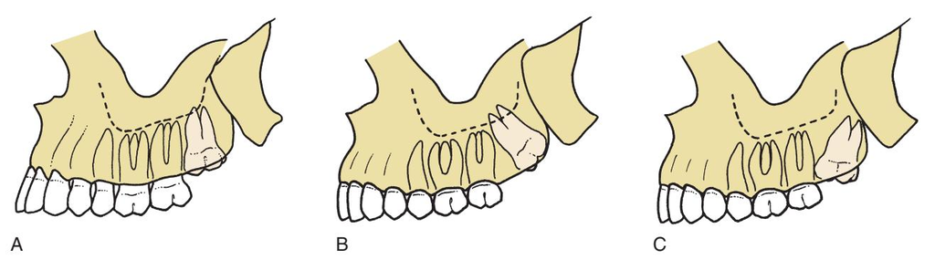

• Fig. 10.39 (A) Vertical impaction of a maxillary third molar. This angle accounts for 63% of impactions. (B) Distoangular impaction of a maxillary third molar. This angle accounts for 25% of impactions. (C) Mesioangular impaction of a maxillary third molar. This angle accounts for 12% of impactions.

##### **Other Factors Influencing Difficulty**

- **Buccopalatal Position:**
  - Most are angled buccally (thin overlying bone, easier removal/expansion).
  - Palatally positioned impacted teeth are much more difficult, requiring greater bone removal and risking injury to palatine nerves/vessels.
  - Determined by radiographic assessment and clinical digital palpation of the tuberosity area (palpable bulge for buccal, bony deficit for palatal).
- **Root Morphology:**
  - Most common difficulty: Thin, nonfused roots with erratic curvature (maxillary third molars have the most erratic root formation).
  - Majority have fused, conical roots. Careful preoperative radiographic examination is crucial.
  - Wider periodontal ligament space simplifies removal; space narrows with age.

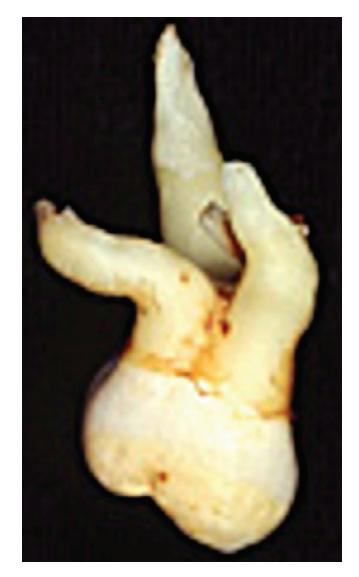

• Fig. 10.40 The maxillary third molar has the most erratic and variable root formation of all teeth. * **Follicle and Bone Density:** A larger follicular sac and more elastic bone (younger patients) simplifies extraction. * **Relationship to Adjacent Second Molar:** May require additional bone removal if tucked under the second molar’s contour. > Be cautious with elevators around large restorations or caries on the second molar to prevent fracture. * **Type of Impaction:** Soft tissue, partial bony, and complete bony impactions have definitions identical to those for mandibular third molars. * **Maxillary Sinus Proximity:** * Maxillary sinus is often in intimate contact with molar roots; third molar may form part of posterior sinus wall. * Increases likelihood of postoperative complications (e.g., sinusitis, oroantral fistula), but doesn’t necessarily make extraction more difficult. * **Tuberosity Fracture:** * Risk of fracture of the posterior maxilla tuberosity (even with erupted teeth). * Increased risk with: * Dense, nonelastic bone (older patients). * Large maxillary sinus (thins alveolar bone). * Divergent roots (require greater force). * Mesioangular impactions (heavier tuberosity, thinner surrounding bone). * Excessive force during elevation, especially when preparing a purchase point at the mesiocervical line. > Management of fractured tuberosity is discussed in Chapter 25.

### **Removal of Other Impacted Teeth**

After third molars, the maxillary canine is the next most commonly impacted tooth.

- **Maxillary Canine Assessment:** The most important assessment is the **buccolingual position** (labial, palatal, or intermediate). Cone-beam CT is the best assessment tool.
  - **Labially positioned:**

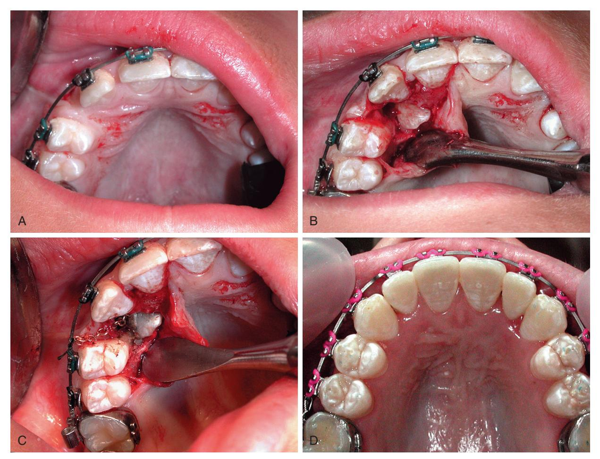

    - A soft tissue flap can be reflected, overlying bone removed, and tooth exposed.
    - For orthodontic repositioning: uncover with an apically positioned flap to preserve attached gingiva. The flap is apically sutured to the tooth after bracket bonding.
  - **Palatally positioned or Intermediate buccolingual position:** Much more difficult to remove or reposition.
    - For orthodontic repositioning: surgically exposed and guided. Overlying soft tissue is excised (flaps not needed for attached tissue). Thicker palatal bone requires a burr for removal.
    - Bracket is luted onto the tooth surface (after etching and priming), commonly with a gold chain to the orthodontic arch wire (provides flexibility, less breakage than wire).
    - Soft tissue sutured for maximum keratinized tissue coverage.
- **Other Impactions (e.g., Mandibular Premolars, Supernumerary Teeth):**
  - Similar considerations apply.
  - **Mesiodens:** Supernumerary tooth in the midline of the maxilla, almost always on the palate, and should be approached from the palatal direction for removal.
- **General Principle:** When sectioning, impacted teeth elsewhere in the mouth are usually sectioned only at the cervical line to permit removal of the crown portion, displacement of the root portion, and then removal of the root portion.

### **Surgical Procedure**

The principles for removing impacted teeth are the same as for other surgical extractions but with distinct differences.

**Five Basic Steps:** 1. **Adequate Exposure:** Reflect a soft tissue flap of sufficient dimensions to allow safe retraction and surgery without damaging the flap. 2. **Bone Removal:** Assess and remove sufficient bone to expose the tooth for sectioning (if needed) and delivery. 3. **Tooth Division (Sectioning):** If needed, divide the tooth with a burr to facilitate extraction without excessive bone removal. Purchase points may also be placed. 4. **Delivery:** Use appropriate elevators to deliver the sectioned or unsectioned tooth from the alveolar process. 5. **Wound Closure:** Smooth bone edges, thoroughly irrigate with sterile solution, and reapproximate the flap with sutures.

**Distinctions from Routine Surgical Extractions:** * **Bone Removal:** Substantially greater and denser bone removal is often required, especially for impacted mandibular third molars, requiring better instrumentation and precision. * **Tooth Sectioning:** Frequently required for impacted teeth, particularly mandibular third molars. The surgeon must have necessary equipment and skills. * **Balance Bone Removal and Sectioning:** Surgeons must balance the amount of bone removed with the extent of tooth sectioning. * Excessive bone removal prolongs healing and may weaken the jaw. * Too little bone removal with multiple tooth divisions prolongs the operation. * Aim: Adequate bone removal and reasonable sectioning to hasten healing and minimize surgical time.

#### **Step 1: Reflecting Adequate Flaps for Accessibility**

- **Purpose:** Gain access and visualize overlying bone. Dimensions must allow retractor and instrument placement/stabilization.
- **Flap Types:**
  - **Envelope Flap:** Preferred technique; quicker to suture, better healing.
  - **Three-Cornered Flap:** (Envelope with releasing incision) Consider if greater access to apical areas is needed to prevent stretching/tearing of an envelope flap.
- **Mandibular Third Molar Incision:**
  - **Preferred:** Envelope incision extending from mesial papilla of mandibular first molar, around necks of teeth, to distobuccal line angle of second molar, then posteriorly to and laterally up the anterior border of the mandibular ramus (Fig. 10.42A). > The incision must not continue posteriorly in a straight line, as the mandible diverges laterally, leading to the incision falling off the bone and into the sublingual space, risking lingual nerve damage. > The incision must always be kept over bone; carefully palpate the retromolar area before incision.
  - Flap reflected laterally with a periosteal elevator to expose the external oblique ridge (Fig. 10.42B). > Do not reflect more than a few millimeters beyond the external oblique ridge to avoid increased morbidity and complications.
  - For deeply embedded impactions, an oblique, vertical releasing incision at the mesial aspect of the second molar may be used (Fig. 10.42C–D).
- **Maxillary Third Molar Incision:**
  - **Recommended:** Envelope incision extending posteriorly over the tuberosity from the distal aspect of the second molar and anteriorly to the mesial aspect of the first molar (Fig. 10.43A–B).
  - For deeply embedded impactions, a release incision extending from the mesial aspect of the second molar can be used (Fig. 10.43C–D).
- **General Flap Principles:**
  - Flap must be large enough for adequate access and visibility.
  - Broad base if a releasing incision is used.
  - Smooth scalpel stroke, kept in contact with bone, to ensure full-thickness mucoperiosteal flap.
  - Designed for closure over solid bone.
  - Avoid vital anatomic structures.

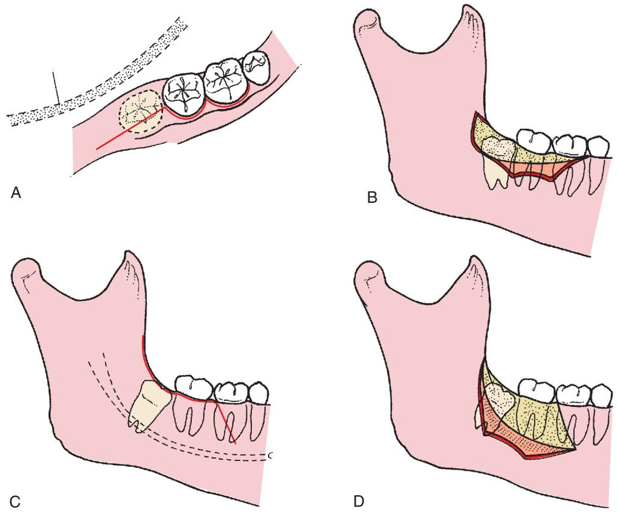

• Fig. 10.42 (A) The envelope incision is most commonly used to reflect soft tissue for removal of the impacted third molar. Posterior extension of the incision should laterally diverge to avoid injury to the lingual nerve. (B) The envelope incision is laterally reflected to expose bone overlying the impacted tooth. (C) When a three-cornered flap is made, a releasing incision is made at the mesial aspect of the second molar. (D) When the soft tissue flap is reflected by means of a releasing incision, greater visibility is possible, especially at the apical aspect of the surgical field.

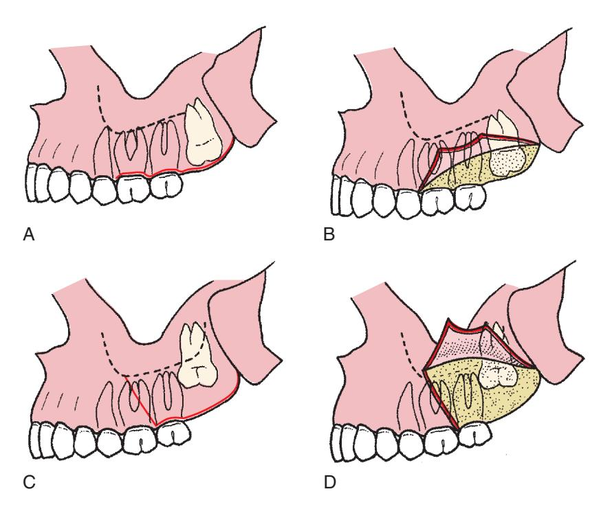

• Fig. 10.43 (A) The envelope flap is the most commonly used flap for the removal of maxillary impacted teeth. (B) When soft tissue is reflected, the bone overlying the third molar is easily visualized. (C) If the tooth is deeply impacted, a releasing incision into the vestibule can be used to gain greater access. (D) When the three-cornered flap is reflected, the more apical portions become more visible.

#### **Step 2: Removal of Overlying Bone**

- **Assessment:** Determine if bone removal is needed (most cases require some). Initial removal is from occlusal, buccal, and distal aspects down to the cervical line. > Bone should not be removed from the lingual aspect of the mandible due to lingual nerve damage risk and it being unnecessary.
- **Burrs:**
  - Large round burr (e.g., No. 8) for end-cutting and a fissure burr (e.g., No. 703) for edge-cutting are useful. > A dental handpiece for restorative dentistry should never be used for bone removal or tooth sectioning around third molars.
- **Mandibular Bone Removal:**
  1. Occlusal bone removed first to expose crown (Fig. 10.44A).
  2. Buccal cortical bone removed down to the cervical line (Fig. 10.44B).
  3. **Ditching:** A trough is created between the tooth and cortical bone to provide elevator access.
- **Maxillary Bone Removal:** Often unnecessary. When required, it is done on the buccal aspect, often with a periosteal elevator instead of a burr.

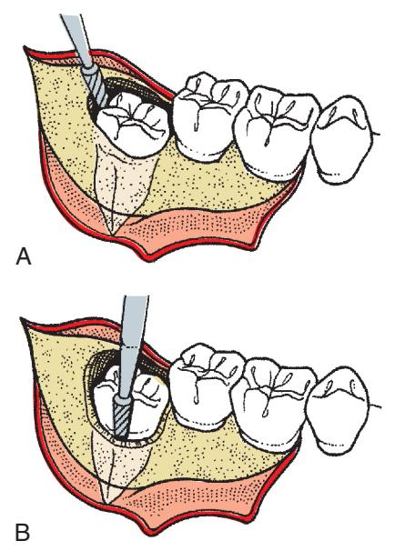

• Fig. 10.44 (A) After soft tissue has been reflected, bone overlying the occlusal surface of the tooth is removed with a fissure burr. (B) The bone on the buccodistal aspect of the impacted tooth is then removed with a burr.

#### **Step 3: Sectioning the Tooth**

- **Purpose:** Allows removal of tooth portions separately, minimizing excessive bone removal. The technique is determined primarily by the angulation of the impacted tooth.
- **Technique:** Performed with a burr, sectioning three-fourths of the way toward the lingual aspect. A straight elevator is inserted into the slot and rotated to split the tooth. > Do not section completely through in the lingual direction to avoid lingual nerve injury.
- **Mandibular Impaction Angulations:**
  - **Mesioangular:** Section off the distal half of the crown, remove this portion, and elevate the remainder (Fig. 10.45).
  - **Horizontal:** Section the crown from the roots, remove the crown, and displace roots into the resulting space (Fig. 10.46).
  - **Vertical:** Section and remove the distal half of the crown, then elevate the remainder (Fig. 10.47).
  - **Distoangular (Most Difficult):** Section the entire crown from the roots, remove the crown, and elevate the roots into the vacated space (Fig. 10.48). This requires more distal bone removal.
- **Maxillary Impactions:** Rarely sectioned. If needed, extraction is usually by bone removal rather than sectioning.

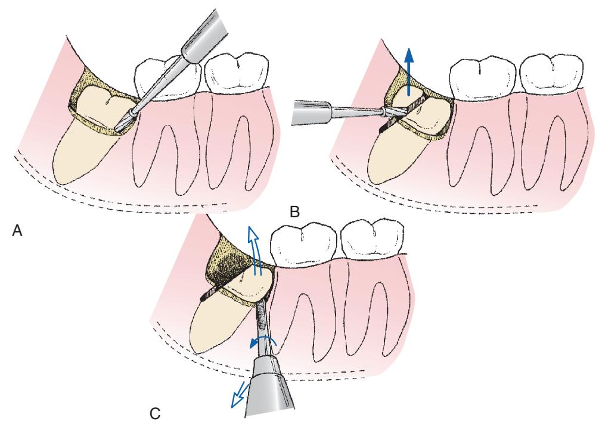

• Fig. 10.45 (A) When removing a mesioangular impaction, buccodistal bone is removed to expose the crown of the tooth to the cervical line. (B) The distal aspect of the crown is then sectioned from the tooth. (C) After the distal portion of the crown has been delivered, a small straight elevator can be inserted into the surgically exposed mesial aspect of the crown to deliver the remainder of the tooth as shown.

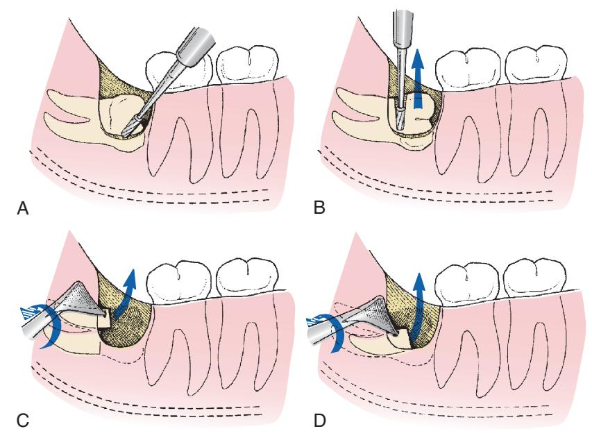

• Fig. 10.46 (A) During the removal of a horizontal impaction, bone overlying the tooth is removed with a burr. (B) The crown is then sectioned from the roots of the tooth and delivered from the socket. (C) Roots are then delivered together or independently by the Cryer elevator used with a rotational motion.

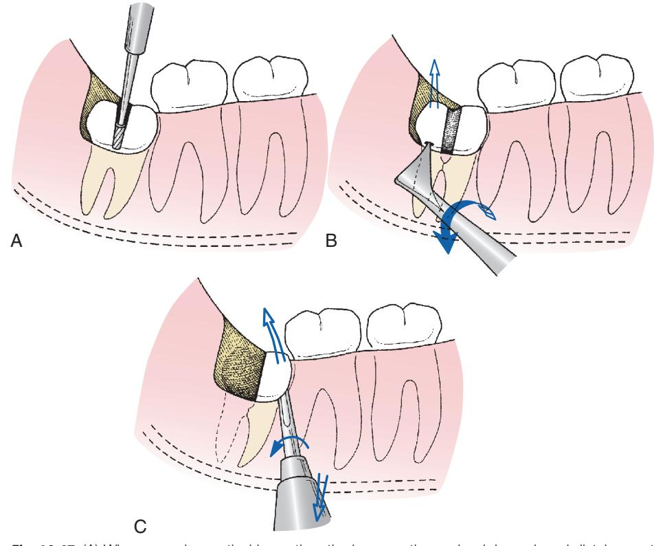

• Fig. 10.47 (A) When removing vertical impaction, the bone on the occlusal, buccal, and distal aspects of the crown is removed and the tooth is sectioned into mesial and distal sections. (B) The posterior aspect of the crown is elevated first with the Cryer elevator inserted into a small purchase point in the distal portion of the tooth. (C) A small straight No. 301 elevator is then used to elevate the mesial aspect of the tooth.

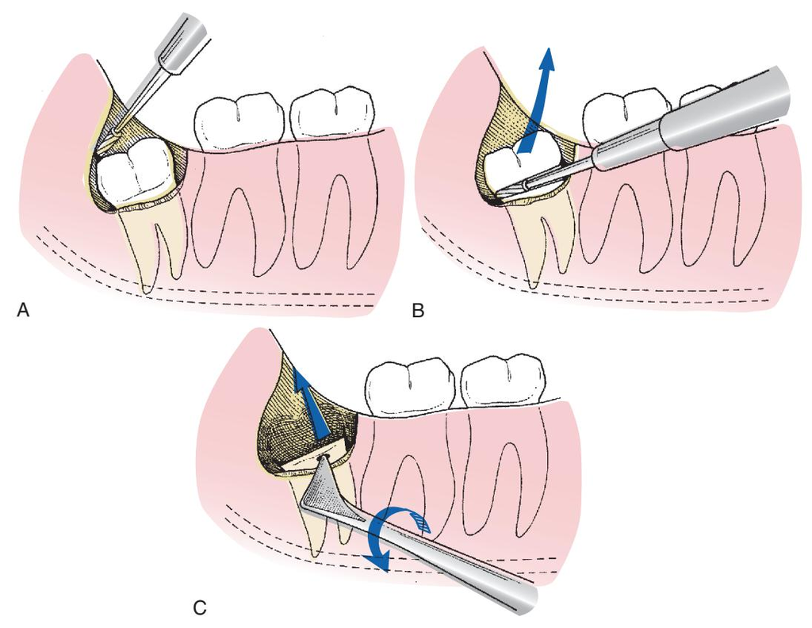

• Fig. 10.48 (A) For distoangular impaction, occlusal, buccal, and distal bone is removed with a burr. (B) The crown of the tooth is sectioned off with a burr, and the crown is delivered with a straight elevator. (C) The purchase point is put into the remaining root portion of the tooth, and the roots are delivered with the Cryer elevator.

#### **Step 4: Delivery of the Sectioned Tooth With Elevator**

- **Mandibular Third Molars:** Delivered with straight, Cryer, or Crane pick elevators. Bone is removed to create an unimpeded pathway rather than expanding cortical plates with luxation. > Application of excessive force may result in unfavorable fracturing of the tooth, excessive buccal bone, the adjacent second molar, or the entire mandible.
- **Maxillary Third Molars:** Delivered with small straight elevators (or angled elevators like Potts, Miller, Warwick) in a distobuccal direction (Fig. 10.49). > Caution: Avoid excessive anterior pressure to prevent damage to the maxillary second molar root. > Palpation: The surgeon should have a finger on the tuberosity to detect/salvage fracture and prevent misdirection of the tooth.

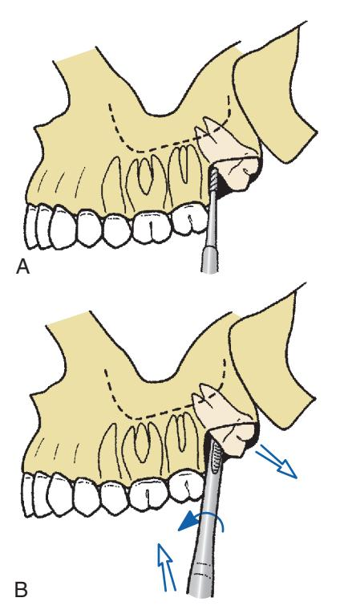

• Fig. 10.49 Delivery of an impacted maxillary third molar. (A) Once soft tissue has been reflected, a small amount of buccal bone is removed with a burr or the pointed end of a periosteal elevator. (B) The tooth is then delivered with a small straight elevator, with a rotary-and-lever type of motion. The tooth is delivered in the distobuccal and occlusal directions.

#### **Step 5: Preparing for Wound Closure**

1. **Bone Smoothing:** Use a bone file to smooth any sharp, rough edges.
2. **Debridement & Irrigation:** Vigorously irrigate with sterile saline to remove all particulate debris.
3. **Follicle Removal:** Grasp and remove any remnants of the dental follicle with a hemostat.
4. **Hemostasis:** Achieve adequate hemostasis, controlling specific bleeding points. > Postoperative bleeding is relatively frequent but usually self-limited if adequate hemostasis is achieved during the operation.
5. **Antibiotic Delivery (Optional):** Some surgeons deliver a topical antibiotic (e.g., tetracycline) into lower third molar sockets to help prevent osteitis sicca (dry socket).
6. **Wound Closure (Primary Closure):** Reapproximate the flap with sutures. Usually 2-3 sutures suffice for an envelope flap.

### **Perioperative Patient Management**

- **Anxiety Control:** IV deep sedation or general anesthesia is highly recommended.
- **Pain Management:** Long-acting local anesthetics and potent oral analgesics (e.g., NSAIDs, codeine combinations) should be prescribed for 3-4 days.
- **Swelling Management:**
  - **Parenteral Corticosteroids:** Preoperative IV glucocorticoids (e.g., 8 mg dexamethasone) are effective at limiting edema. > Few side effects, but risks/benefits must be weighed.
  - **Ice Packs:** Provide comfort but are unlikely to prevent swelling.
- **Antibiotics:**
  - Indicated for preexisting infections. Not indicated for healthy patients without local infection.
  - Topical antibiotics (e.g., minocycline) have been shown to greatly lower the incidence of osteitis sicca (dry socket) in mandibular molar sites.
- **Normal Postoperative Experience:**
  - **Edema:** Modest swelling for 3-4 days, resolving by 5-7 days.
  - **Discomfort:** Modest, controllable with oral analgesics for 2-3 days.
  - **Trismus:** Mild to moderate inability to open mouth, resolving by 7-10 days. > Investigate if pain, edema, and trismus have not greatly improved by 7 days after surgery.
  - **Age:** Sequelae are less intense in younger patients and significantly greater in adults over 35-40 years old.

### **Bibliography**

- American Association of Oral and Maxillofacial Surgeons. White Paper on Third Molar Data. www.aaoms.org/docs/third_molar_white_ paper.pdf. 2007.
- Bean LR, King DR. Pericoronitis: Its nature and etiology. J Am Dent Assoc. 1971;83:1074.
- Pell GJ, Gregory GT. Report on a ten-year study of a tooth division technique for the removal of impacted teeth. *Am J Orthod.* 1942;28:660.
- Perciaccante VJ. Management of impacted teeth. Oral Maxillofac Surg Clin North Am. 2007;19:1–140.
- Proceedings from the Third Molar Multidisciplinary Conference. J Oral Maxillofac Surg. 2012;70(suppl 1):S1–S70.